# Problema 3 - Checkpoint 1

Marcos Antonio Silva Nascimento (marcos.nascimento@ccc.ufcg.edu.br)

16 de junho de 2017

```r
library(tidyverse, warn.conflicts = F)
library(rvest)
```

```r
library(plotly)
library(cluster)
library(ggdendro)
theme_set(theme_light())
source("plota_solucoes_hclust.R")

from_page <- read_html("https://www.rottentomatoes.com/celebrity/lindsay_lohan") %>%
    html_node("#filmographyTbl") %>% # A sintaxe da expressão é de um seletor à lá JQuery: https://rdrr.io/cran/rvest/man/html_nodes.html
    html_table(fill=TRUE) %>% # Faz parse
    as.tibble()

filmes = from_page %>%
    filter(RATING != "No Score Yet",
           `BOX OFFICE` != "—",
            CREDIT != "Executive Producer") %>%
           mutate(RATING = as.numeric(gsub("%", "", RATING)),
           `BOX OFFICE` = as.numeric(gsub("[$|M|k]", "", `BOX OFFICE`))) %>%
    filter(`BOX OFFICE` != 'NA') # Tem sete filmes que não parecem ter sido lançados no mundo todo
```

# Tipos de filme de Lindsay Lohan

Neste post vamos investigar a existência de grupos de filmes com comportamentos comuns para os atuados pela atriz Lindsay Lohan. Previamente a atriz parece ter atuado em alguns filmes mais frequentemente quando fazia parte das estrelas Disney e nos dias atuais de forma mais esporádica. Será que existem grupos que definem comportamentos comuns para os filmes da atriz levando em consideração o sucesso de público e a crítica? Utilizaremos os dados cedidos pelo site Rotten Tomatoes.

Antes de mais nada precisamos descrever as variáveis que serão utilizadas para ver se já delineam a existência de grupos comuns de filmes.

## A descrição

Vamos primeiramente olhar para o gráfico abaixo, veja como se comporta a distribuição de avaliação de cada filme da atriz.

```r
dist_avaliacao = filmes %>%
  ggplot(aes(x = "Filmes", y = RATING, label = TITLE)) +
    geom_jitter(width = .01, height = 0, size = 2, alpha = .6, color = "red") +
  labs(title = "Distribuição da avaliação do filme", x="Filmes", y="Avaliação") +
  theme(plot.title = element_text(hjust = 0.5))

ggplotly(dist_avaliacao)
```

[interactive chart not shown]

Observando as avaliações dos filmes podemos observar uma tendência de grupos. Esses grupos ficam ainda mais evidentes quando geramos o gráfico de contagem de frequência de cada avaliação (vide abaixo). As avaliações mais próximas poderiam sugerir os grupos e os gaps os delimitadores entre cada um deles.

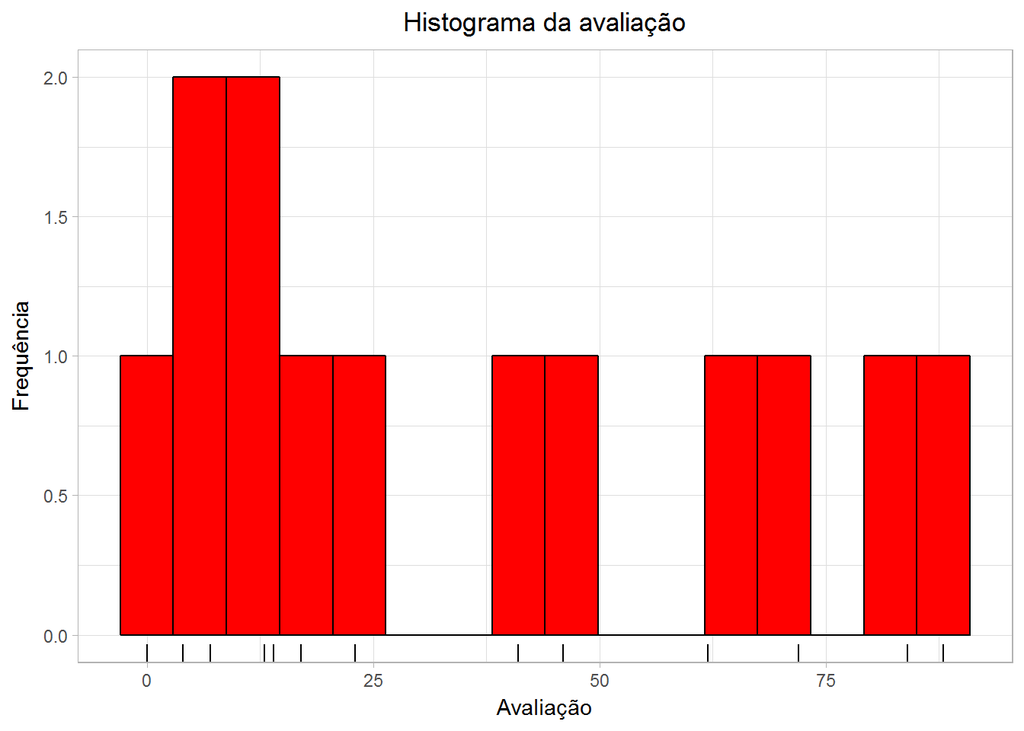

```r
filmes %>%
    ggplot(aes(x = RATING)) +
    geom_histogram(bins = 16, fill = "red", color = "black") +
    geom_rug() +
   labs(title = "Histograma da avaliação", x="Avaliação", y = "Frequência") +
  theme(plot.title = element_text(hjust = 0.5))
```

Veja como se comporta a distribuição da renda de cada filme da atriz.

```r
dist_renda = filmes %>%
    ggplot(aes(x = "Filmes", y = `BOX OFFICE`, label = TITLE)) +
    geom_jitter(width = .02, height = 0, size = 2, alpha = .6, color = "red") +
  labs(title = "Distribuição da bilheteria", x="Filmes", y="Bilheteria") +
  theme(plot.title = element_text(hjust = 0.5))
ggplotly(dist_renda)
```

[interactive chart not shown]

Podemos ver uma estrutura de grupo de filmes bem próximos quanto ao sucesso de público. O maior grupo define os filmes com bilheteria inferior a 40 milhões de dólares. Ainda sobre a bilheteria podemos observar se os valores de bilheteria são frequentes.

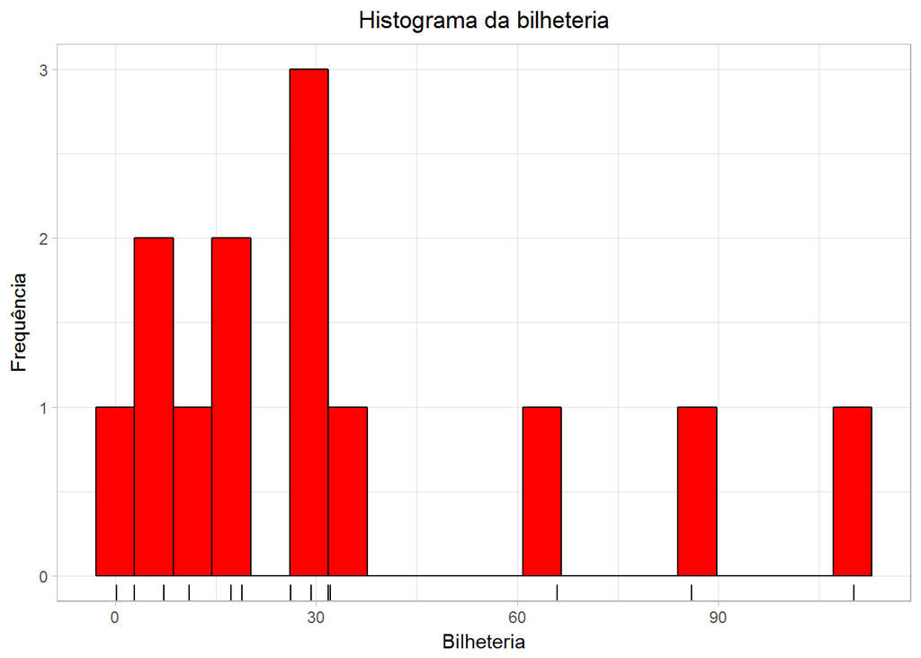

```r
filmes %>%
    ggplot(aes(x = `BOX OFFICE`)) +
    geom_histogram(bins = 20, fill = "red", color = "black") +
    geom_rug() +
  labs(title = "Histograma da bilheteria", x="Bilheteria", y = "Frequência") +
  theme(plot.title = element_text(hjust = 0.5))
```

Quanto a frequência de bilheterias comuns observamos que a maioria dos valores de bilheteria são distintos e existem poucos valores duplicados. Poderia ser interessante analisar o comportamento da distribuição de bilheteria dos filmes em uma outra escala já que a maior concentração de valores de bilheteria impede uma melhor visualização da real magnitude dos valores.

```r
dist_renda_logscale = filmes %>%
    ggplot(aes(x = "Filmes", y = `BOX OFFICE`, label=TITLE)) +
    geom_jitter(width = .02, height = 0, size = 2, alpha = .6, color = "red") +
    scale_y_log10() +
  labs(title = "Distribuição da bilheteria", x="Filmes", y="Bilheteria") +
  theme(plot.title = element_text(hjust = 0.5))
ggplotly(dist_renda_logscale)
```

[interactive chart not shown]

Um valor de bilheteria que anteriormente parecia fazer parte de um grupo majoritário de valores contém o menor valor de bilheteria. Isso fica ainda mais evidente se olharmos o gráfico de histograma abaixo para a contagem de frequência de bilheteria de cada filme na escala logarítimica.

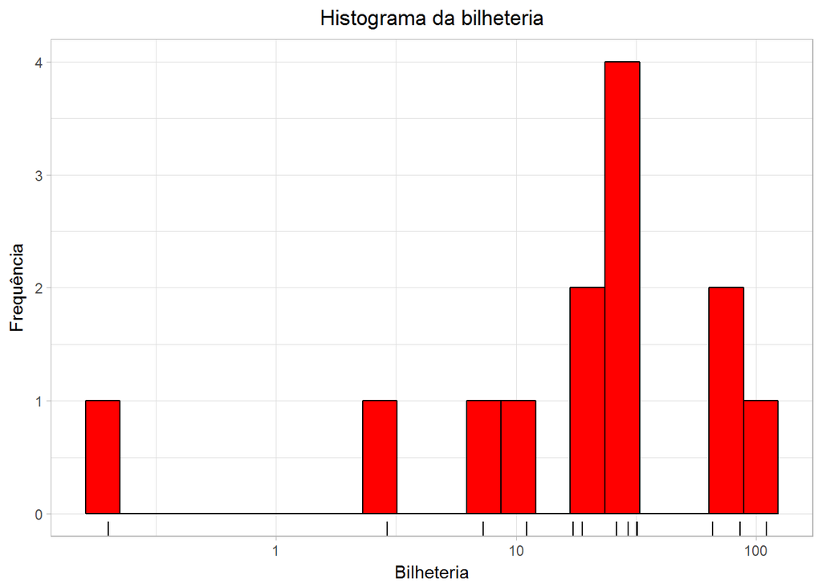

```r
filmes %>%
    ggplot(aes(x = `BOX OFFICE`)) +
    geom_histogram(bins = 20, fill = "red", color = "black") +
    scale_x_log10() +
    geom_rug() +
  labs(title = "Histograma da bilheteria", x="Bilheteria", y = "Frequência") +
  theme(plot.title = element_text(hjust = 0.5))
```

# Agrupamento com duas dimensões

## Sem normalização e sem transformação

Podemos perceber pela descrição das variáveis que a crítica e a bilheteria já tendenciam a estrutura de grupos mas como ficaria o gráfico de distribuição dessas duas variáveis?

```r
dist_avaliacao_renda = filmes %>%
    ggplot(aes(x = RATING, y = `BOX OFFICE`, label = TITLE)) +
    geom_point(color="red") +
  labs(title = "Distribuição da avaliação e da bilheteria", x="Avaliação", y="Bilheteria") +
  theme(plot.title = element_text(hjust = 0.5))
ggplotly(dist_avaliacao_renda)
```

[interactive chart not shown]

Quais seriam os possíveis grupos para esta distribuição bidimensional?

```r
agrupamento_h_2d = filmes %>%
    column_to_rownames("TITLE") %>%
    select(RATING, `BOX OFFICE`) %>%
    dist(method = "euclidean") %>%
    hclust(method = "centroid")
```

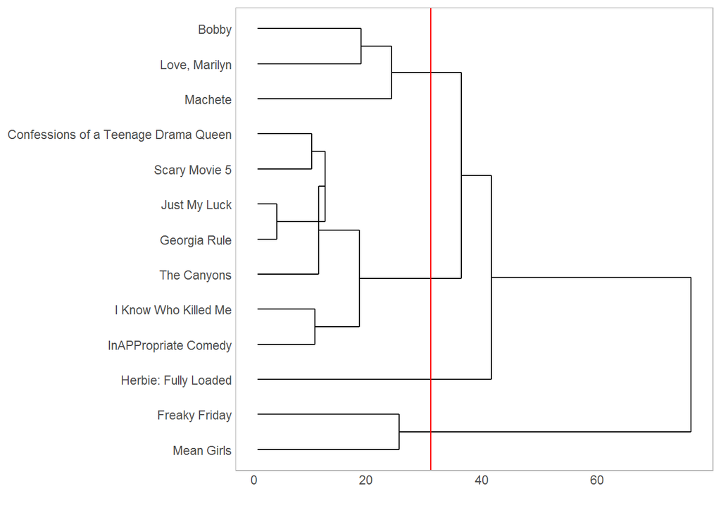

```r
ggdendrogram(agrupamento_h_2d, rotate = TRUE) +
  geom_hline(yintercept = 30, colour = "red")
```

Observando o gráfico do dendrograma acima fica apropriado escolher 4 grupos já que os mesmos vão conter filmes menos distintos e mais característicos daquele grupo no qual estão inseridos. Como ficariam dispostos os nossos grupos de filmes?

```r
plota_hclusts_2d(agrupamento_h_2d,
                 filmes,
                 c("RATING", "`BOX OFFICE`"),
                 linkage_method = "centroid", ks = 1:6) %>% ggplotly()
```

[interactive chart not shown]

Escolhendo 4 grupos esta escolha agruparia filmes característicos do grupo no qual estariam inseridos?

```r
distancias = filmes %>%
    column_to_rownames("TITLE") %>%
    select(RATING, `BOX OFFICE`) %>%
    dist(method = "euclidean")
```

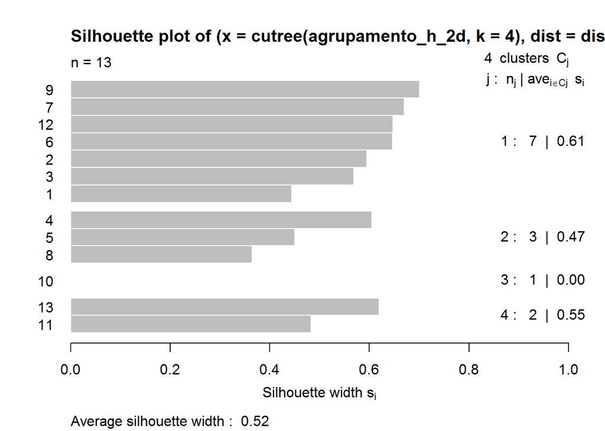

```r
plot(silhouette(cutree(agrupamento_h_2d, k = 4), distancias))
```

Observando o gráfico acima parece que sim porque cada grupo contém filmes característicos daquele grupo.

## Com normalização e com transformação

Na seção anterior não fizemos normalização ou padronização dos dados antes de reuni-los em clusters, isto seria adequado? Seria certo ou justo comparar variáveis de escalas divergentes e afirmar algo sensato? Você certamente deve estar ciente que não.

A técnica de transformação não foi aplicada na seção anterior. Seria apropriado afirmar algo sobre grupos de valores em um gráfico sem observar como o mesmo se comporta em uma outra escala? A resposta mais sensata também seria não. Na seção de descrição das variáveis notamos que um filme que teve a pior bilheteria não foi distinto de um grupo com valores de bilheterias maiores. Como levar isso em consideração?

Veja como fica o gráfico de distribuição da crítica e da renda quando observamos a renda na escala logarítimica.

```r
dist_avaliacao_renda = filmes %>%
    ggplot(aes(x = RATING, y = `BOX OFFICE`, label = TITLE)) +
    geom_point(color="red") +
  scale_y_log10() +
  labs(title = "Distribuição da avaliação e da bilheteria", x="Avaliação", y="Bilheteria") +
  theme(plot.title = element_text(hjust = 0.5))
ggplotly(dist_avaliacao_renda)
```

[interactive chart not shown]

Quais seriam os possíveis grupos para esta distribuição bidimensional se as variáveis fossem normalizadas e o eixo de bilheteria fosse transformado para a escala logarítimica?

```r
agrupamento_h_2d = filmes %>%
    column_to_rownames("TITLE") %>%
    select(RATING, `BOX OFFICE`) %>%
    mutate(`BOX OFFICE` = log10(`BOX OFFICE`)) %>%
    mutate_all(funs(scale)) %>%
    dist(method = "euclidean") %>%
    hclust(method = "centroid")
```

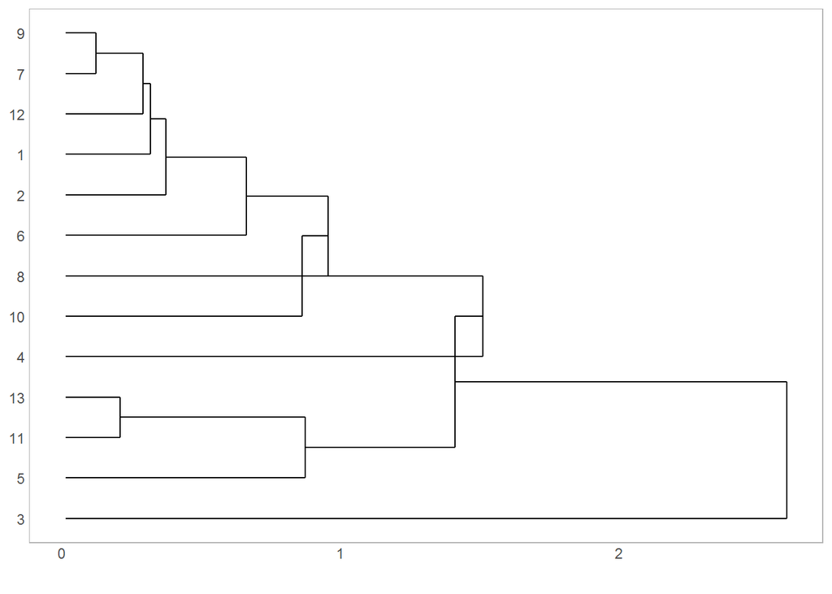

```r
ggdendrogram(agrupamento_h_2d, rotate = TRUE)
```

```r
filmes2 = filmes %>% mutate(`BOX OFFICE` = log10(`BOX OFFICE`))
ggplotly(plota_hclusts_2d(agrupamento_h_2d,
                 filmes2,
                 c("RATING", "`BOX OFFICE`"),
                 linkage_method = "ward.D", ks = 1:6) + scale_y_log10())
```

[interactive chart not shown]

Escolhendo 4 grupos esta escolha ainda agruparia filmes característicos do grupo no qual estariam inseridos?

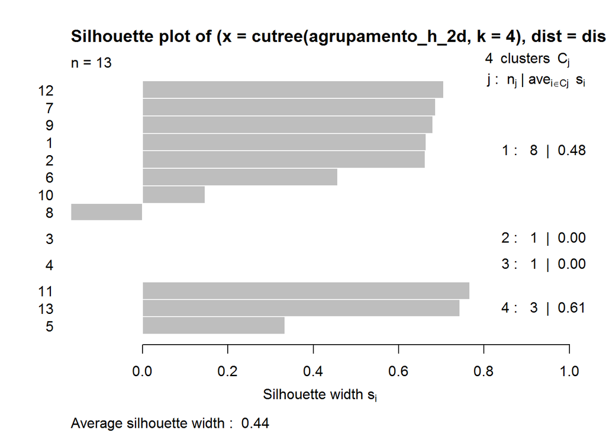

```r
distancias = filmes %>%
    column_to_rownames("TITLE") %>%
    select(RATING, `BOX OFFICE`) %>%
    mutate(`BOX OFFICE` = log10(`BOX OFFICE`)) %>%
    mutate_all(funs(scale)) %>%
    dist(method = "euclidean")

plot(silhouette(cutree(agrupamento_h_2d, k = 4), distancias))
```

Observando o gráfico acima parece que esta escolha agrupa um filme em um agrupamento que não lhe caracteriza tão bem embora isso não vá fazer tanta diferença e impactar tanto na análise.

# Conclusão

O ideal é realizar a normalização com transformação da variável bilheteria. Uma escolha dos grupos poderia ser 4. Esta escolha agruparia os filmes da atriz sem prejuízo de informação. Os nomes para os grupos seriam: os **piores filmes**, os **filmes medianos**, os **filmes que você deveria ver** e os **melhores filmes**.

Os **piores filmes** são aqueles que não fizeram sucesso de público e nem foram bem avaliados (por ex. InAPPropriate Comedy). Os **filmes medianos** são aqueles que tiveram um sucesso considerável de público e ainda assim não foram bem avaliados (por ex. The Canyons). Os **filmes que você deveria ver** aqueles filmes que foram bem avaliados mas não tiveram sucesso de público (por ex. Love, Marilyn) e os **melhores filmes** aqueles que tiveram sucesso de público e de avaliação (por ex. Mean Girls).